# Notebook

### Web Information Retrieval and Data Mining - Assignment 3

```
Student: Merz, Gerrit (1553410)
```

#### Answer 1.1, Baseline (4p)

- Dense network, at least 3 layers, shaped like a pyramid
  - Last layer: 10 nodes, sigmoid.
  - Loss: categorical cross-entropy. Metric: accuracy
- No preprocessing, regularization. Get at least 70% accuracy.
- Explain design decisions. Discuss performance.
  - Does it overfit (large/growing gap between loss and val_loss)?

[output not shown]

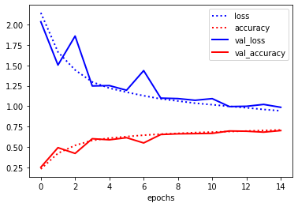

```
Model: "sequential_36"
_________________________________________________________________
Layer (type)                 Output Shape              Param #
=================================================================
reshape (Reshape)            (None, 3072)              0
_________________________________________________________________
dense_72 (Dense)             (None, 128)               393344
_________________________________________________________________
dense_73 (Dense)             (None, 64)                8256
_________________________________________________________________
dense_74 (Dense)             (None, 32)                2080
_________________________________________________________________
dense_75 (Dense)             (None, 10)                330
=================================================================
Total params: 404,010
Trainable params: 404,010
Non-trainable params: 0
_________________________________________________________________
None
def build_model_1_1():
  model = models.Sequential()
  model.add(layers.Reshape((3072,), input_shape=(32,32,3)))
  model.add(layers.Dense(128, activation='relu'))
  model.add(layers.Dense(64, activation='relu'))
  model.add(layers.Dense(32, activation='relu'))
  model.add(layers.Dense(10, activation='softmax'))
  model.compile(optimizer='rmsprop',
                loss='categorical_crossentropy',
                metrics=['accuracy'])
  return model
```

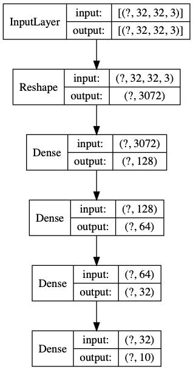

#### Answer 1.2, Preprocess (2p)

- Convert images to greyscale, other preprocessing optional.
  - Input shape should be (32,32,1)
- Explain design decisions. Is it better? Why (not)?
  - Color information is likely not so useful for classification. Greyscale makes the network smaller, less parameters to learn, less likely to overfit.

[output not shown]

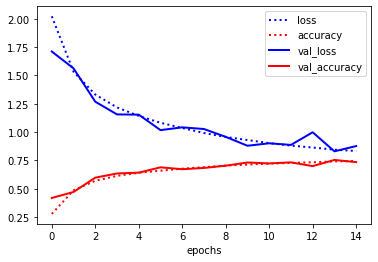

```
Model: "sequential_21"
_________________________________________________________________
Layer (type)                 Output Shape              Param #
=================================================================
reshape_21 (Reshape)         (None, 1024)              0
_________________________________________________________________
dense_92 (Dense)             (None, 128)               131200
_________________________________________________________________
dense_93 (Dense)             (None, 64)                8256
_________________________________________________________________
dense_94 (Dense)             (None, 32)                2080
_________________________________________________________________
dense_95 (Dense)             (None, 10)                330
=================================================================
Total params: 141,866
Trainable params: 141,866
Non-trainable params: 0
_________________________________________________________________
None
def build_model_1_2():
  model = models.Sequential()
  model.add(layers.Reshape((1024,), input_shape=(32,32,1)))
  model.add(layers.Dense(128, activation='relu'))
  model.add(layers.Dense(64, activation='relu'))
  model.add(layers.Dense(32, activation='relu'))
  model.add(layers.Dense(10, activation='softmax'))
  model.compile(optimizer='rmsprop',
                loss='categorical_crossentropy',
                metrics=['accuracy'])
  return model
```

#### Answer 1.3, Tune (4p)

- Regularize the model. What works best?
  - Should consider batch normalization, dropout, l1/l2 regularization (or Nesterov)
- Tune other hyperparameters (e.g. learning rate, batch size,...) as you see fit.
  - At least consider tuning learning rate, ideally also momentum, decay, other optimizers
- Explain your findings and final design decisions. Discuss the results.
  - Should be better, at least it shouldn't overfit

[output not shown]

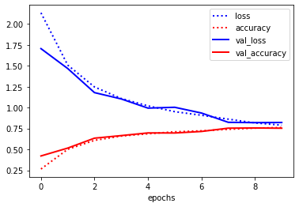

```
def build_model_1_3():

  model = models.Sequential()
  model.add(layers.Reshape((1024,), input_shape=(32,32,1)))
  model.add(layers.Dense(1024, activation='relu'))
  model.add(layers.Dense(512, activation='relu'))
  model.add(layers.Dense(256,  activation='relu'))
  model.add(layers.Dense(256, kernel_regularizer=regularizers.l2(0.001), activation='relu'))
  model.add(layers.Dense(128, kernel_regularizer=regularizers.l2(0.001), activation='relu'))
  model.add(layers.Dense(10, activation='softmax'))
  model.compile(optimizer='adam',
                loss='categorical_crossentropy',
                metrics=['accuracy'])
  return model
```

#### Answer 2.1, ConvNet (7p)

- Build a sequential ConvNet, get at least 90% accuracy.
  - Conv2D layers, input shape (32,32,1)
  - Consider using blocks of Conv2D layers with maxpooling in between
  - Use zero-padding in Conv2D layers because the images are small
  - At least one dense hidden layer and dense output layer (sigmoid)
  - Consider adding batch normalization, dropout
  - Consider small dropout rates in beginning, larger dropout rates later in network
  - Consider other optimizers and tuning learning rate, momentum,...
- Explain what you did and why (800 chars). Is it working well?
  - Should be quite elaborate and sensible

[output not shown]

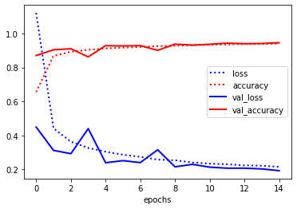

```
Model: "sequential_42"
_________________________________________________________________
Layer (type)                 Output Shape              Param #
=================================================================
conv2d_108 (Conv2D)          (None, 32, 32, 32)        320
_________________________________________________________________
batch_normalization_126 (Bat (None, 32, 32, 32)        128
_________________________________________________________________
conv2d_109 (Conv2D)          (None, 32, 32, 32)        9248
_________________________________________________________________
batch_normalization_127 (Bat (None, 32, 32, 32)        128
_________________________________________________________________
max_pooling2d_54 (MaxPooling (None, 16, 16, 32)        0
_________________________________________________________________
dropout_81 (Dropout)         (None, 16, 16, 32)        0
_________________________________________________________________
conv2d_110 (Conv2D)          (None, 16, 16, 64)        18496
_________________________________________________________________
batch_normalization_128 (Bat (None, 16, 16, 64)        256
_________________________________________________________________
conv2d_111 (Conv2D)          (None, 16, 16, 64)        36928
_________________________________________________________________
batch_normalization_129 (Bat (None, 16, 16, 64)        256
_________________________________________________________________
max_pooling2d_55 (MaxPooling (None, 8, 8, 64)          0
_________________________________________________________________
dropout_82 (Dropout)         (None, 8, 8, 64)          0
_________________________________________________________________
conv2d_112 (Conv2D)          (None, 8, 8, 64)          36928
_________________________________________________________________
batch_normalization_130 (Bat (None, 8, 8, 64)          256
_________________________________________________________________
conv2d_113 (Conv2D)          (None, 8, 8, 64)          36928
_________________________________________________________________
batch_normalization_131 (Bat (None, 8, 8, 64)          256
_________________________________________________________________
max_pooling2d_56 (MaxPooling (None, 4, 4, 64)          0
_________________________________________________________________
dropout_83 (Dropout)         (None, 4, 4, 64)          0
_________________________________________________________________
```

[output cut: 30 more lines]

```
  model.add(layers.BatchNormalization())
  model.add(layers.Conv2D(64, (3, 3), activation='relu', padding='same'))
  model.add(layers.BatchNormalization())
  model.add(layers.MaxPooling2D((2, 2)))
  model.add(layers.Dropout(0.5))
  model.add(layers.Flatten())
  model.add(layers.Dense(100, activation='relu'))
  model.add(layers.BatchNormalization())
  model.add(layers.Dropout(0.5))
  model.add(layers.Dense(10, activation='softmax'))
  model.compile(optimizer='rmsprop',
                loss='categorical_crossentropy',
                metrics=['accuracy'])

  return model
```

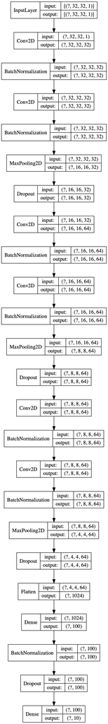

#### Answer 2.2, Data Augmentation (3p)

- Augment the preprocessed training data.
  - Use small variations (small shifts up-down, left-right) of flips becasue the images are small
  - Large shifts and rotations distort the image too much
- Explain what you did and why. Discuss the performance of the model.

[output not shown]

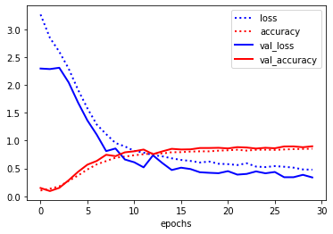

```
train_datagen = ImageDataGenerator(
    #rotation_range=30,
    zoom_range=0.1,
    #width_shift_range=0.2,
    #height_shift_range=0.2,
    shear_range=0.1
    #horizontal_flip=True,
    #fill_mode="nearest"
)
```

#### Answer 3.1, Misclassifications (2p)

[output not shown]

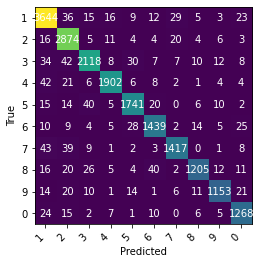

[figure not shown]

#### Answer 3.2, Activations (4p)

- Retrieve and visualize the activations for one example
- For every filter for different convolutional layers (at different depths in the network).
- Give an explanation. Is your model indeed learning something useful?
  - Should detect edges etc in first layers, higher-order object (e.g. interesting regions) in deeper layers.

[output not shown]

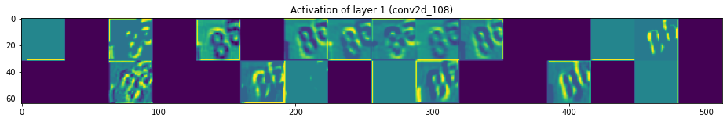

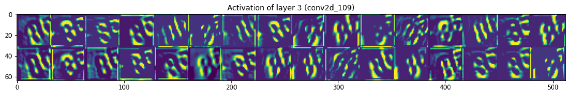

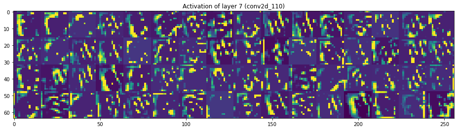

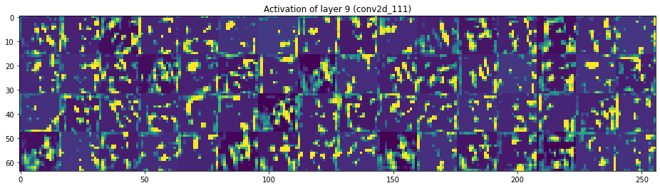

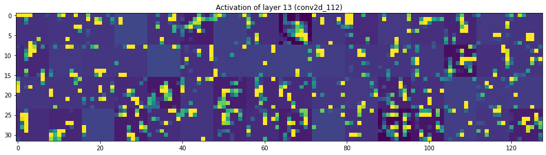

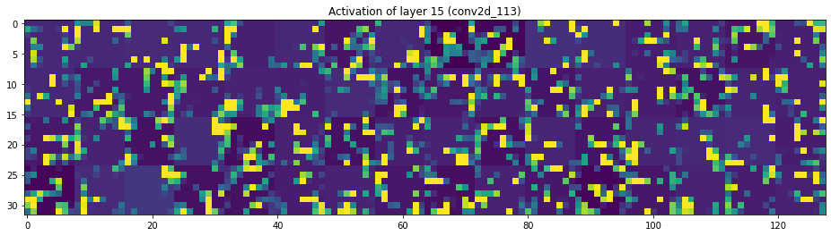

#### Answer 3.3, Class activation map (4p)

- Show a class activation map for your last convolutional layer
- Superimpose the activation map over the image, or plot side by side
  - Should make sense, detect interesting regions to classify the number

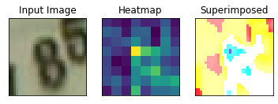

```
def plot_3_3():
  img = X_test_gr[0]
  img = np.expand_dims(img, axis = 0)
  model_2_2 =  load_model_from_file(base_dir, 'model_2_1')
  last_conv_layer = model_2_2.get_layer('conv2d_113')
  eight_output = model_2_2.output[:, 7]
  grads = K.gradients(eight_output, last_conv_layer.output)[0]
  pooled_grads = K.mean(grads, axis=(0, 1, 2))
  iterate = K.function([model_2_2.input], [pooled_grads, last_conv_layer.output[0]])
  pooled_grads_value, conv_layer_output_value = iterate(img)

  for i in range(64):
      conv_layer_output_value[:, :, i] *= pooled_grads_value[i]
  img = X_test_gr[0]
  plt.subplot(131)
  plt.imshow(X_test[0])
  plt.title('Input Image')
  plt.xticks([])
  plt.yticks([])
  plt.plot()

  heatmap = np.mean(conv_layer_output_value, axis=-1)
  heatmap = np.maximum(heatmap, 0)
  heatmap /= np.max(heatmap)

  plt.subplot(132)
  plt.xticks([])
  plt.yticks([])
  plt.imshow(heatmap)
  plt.title('Heatmap')

  heatmap = cv2.resize(heatmap, (img.shape[1], img.shape[0]))
  heatmap = np.uint8(255 * heatmap)
  heatmap = cv2.applyColorMap(heatmap, cv2.COLORMAP_JET)

  superimposed_img = heatmap + img
  plt.subplot(133)
  plt.rcParams['figure.dpi'] = 120
  plt.imshow(superimposed_img)
  plt.title('Superimposed')
  plt.xticks([])
  plt.yticks([])
  plt.plot()

  plt.show()
```

#### Answer 4.1, Fast feature extraction (5p)

- Import the VGG16 model, pretrained on ImageNet
- Freeze convolutional base, adds a dense layer
- Consider unfreezing the last few convolutional layers and evaluate whether that works better
  - Check if they do. It is very likely to help.
- Discuss the observed performance
  - Should get around 80% accuracy

[output not shown]

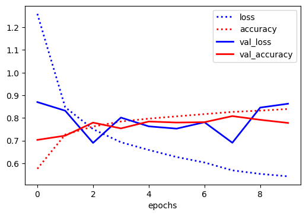

```
Model: "sequential_44"
_________________________________________________________________
Layer (type)                 Output Shape              Param #
=================================================================
vgg16 (Model)                (None, 1, 1, 512)         14714688
_________________________________________________________________
flatten_20 (Flatten)         (None, 512)               0
_________________________________________________________________
dense_166 (Dense)            (None, 512)               262656
_________________________________________________________________
dense_167 (Dense)            (None, 10)                5130
=================================================================
Total params: 14,982,474
Trainable params: 7,347,210
Non-trainable params: 7,635,264
_________________________________________________________________
None
def build_model_4_1():
  #Get back the convolutional part of a VGG network trained on ImageNet
  vgg = VGG16(weights='imagenet', include_top=False, input_shape=(32,32,3))
  model = models.Sequential()
  model.add(vgg)
  model.add(layers.Flatten())
  model.add(layers.Dense(512, activation='relu'))
  model.add(layers.Dense(10, activation='softmax'))

  #unfreeze last three convolutional layers
  for layer in vgg.layers:
      if layer.name in ('block5_conv1','block5_conv2','block5_conv3'):
          layer.trainable = True
      else:
          layer.trainable = False

  model.compile(optimizer='rmsprop',
                loss='categorical_crossentropy',
                metrics=['accuracy'])

  return model
```

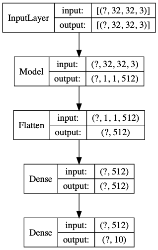

#### Answer 4.2, Embeddings (5p)

- Generate embeddings with the trained convolutional part of model_4_1 (without the dense layer)
- Embed the training and test data and store them to disk
- Build and evaluate a pipeline on the embedded data
  - Check if pipeline makes sense (e.g. use models that can handle many dimensions)
- Describe what you did and what you observed (max 800 chars).
  - Consider different models, preprocessing, tuning, etc.
  - Check performance (see original Submission.html) when in doubt. We did not run all the evaluations because it takes too long, and the output is ill-defined.

[output not shown]

```
Running time: 47.74 seconds
Last modified: May 26, 2020
scikit-learn version: 0.23.1
```